# Getting Started

## 1. Jupyter Notebooks

Jupyter is a web application that allows you to run live code, embed visualizations and explanatory text all in one place. It has kernels that run and introspect's the user's code and allows for interactive and exploratory features.

Jupyter is typically installed on your machine using Anaconda (helps manages packages, notebooks etc.) so that you can locally host your own notebooks. For the purpose of this tutorial, the University of Waterloo hosts user servers for us to use Jupyter Notebooks with.

### Instructions:

1. Login at https://jupyter.math.uwaterloo.ca/
2. Select `Python 2` as the language.
3. Test everything works, by typing in:

```python
for i in range(5):
    print 'Joanna' + str(i)
```

```
Joanna0
Joanna1
Joanna2
Joanna3
Joanna4
```

## 2. Working with Data

https://www.kaggle.com/c/titanic/data

### Instructions:

1. Download the data from the link above.
2. Note the data dictionary provided

| Variable | Definition | Key |
| --- | --- | --- |
| survival | Survival | 0 = No, 1 = Yes |
| pclass | Ticket class | 1 = 1st, 2 = 2nd, 3 = 3rd |
| sex | Sex |  |
| Age | Age in years |  |
| sibsp | # of siblings / spouses aboard the Titanic |  |
| parch | # of parents / children aboard the Titanic |  |
| ticket | Ticket number |  |
| fare | Passenger fare |  |
| cabin | Cabin number |  |
| embarked | Port of Embarkation | C = Cherbourg, Q = Queenstown, S = Southampton |

/3. Upload the file onto your Jupyter notebook for access.

### Types of Data:

The data has been split into two groups:

- training set (train.csv)
- test set (test.csv)

The training set should be used to build your machine learning models. For the training set, Kaggle provides the outcome (also known as the “ground truth”) for each passenger. Your model will be based on “features” like passengers’ gender and class. You can also use feature engineering to create new features.

The test set should be used to see how well your model performs on unseen data. For the test set, Kaggle does not provide the ground truth for each passenger. It is your job to predict these outcomes. For each passenger in the test set, use the model you trained to predict whether or not they survived the sinking of the Titanic.

## 3. Getting Ready For Data Analysis

We import some useful Python libraries.

**os** is a built-in library to do operating system related things. We mostly use the os.path.join() function to access the file we want. Different operating systems store their files in different ways and python easily does the work for us. Ex. Windows might have a path like "C:\Users\scientist\Desktop" while linux may have "~/Desktop".

**matplotlib** is used to plot any data we have. It's a very flexible library from plotting basic scatter plots to doing animations of geographical maps.

**pandas** is used to store our data into something called a dataframe (as you will see shortly). The library allows us to apply functions on the dataframe to allow us to easily extract certain parts of the data, apply functions (ex. mean) on the data, and much more. If you are already aware of this concept, pandas has a good cheatsheet here.

**numpy** is a scientific computing library that allows for more speedy computations and useful tools such as linear algebra

**seaborn** tool for plotting!

### Step 1: Import relevant libraries

```python
import os

import matplotlib.pyplot as plt
%matplotlib inline
import numpy as np
import pandas as pd
import seaborn as sns
sns.set()
```

### Step 2: Read in the data

```python
train = pd.read_csv('./all/train.csv')
test = pd.read_csv('./all/test.csv')
```

### Step 3: Check data has been imported correctly

```python
print train.shape
```

```
(891, 12)
```

You can view the first n or last n observations using dataframe.head(n) and dataframe.tail(n) respectively.

```python
train.head(3)
```

|  | PassengerId | Survived | Pclass | Name | Sex | Age | SibSp | Parch | Ticket | Fare | Cabin | Embarked |
| --- | --- | --- | --- | --- | --- | --- | --- | --- | --- | --- | --- | --- |
| 0 | 1 | 0 | 3 | Braund, Mr. Owen Harris | male | 22.0 | 1 | 0 | A/5 21171 | 7.2500 | NaN | S |
| 1 | 2 | 1 | 1 | Cumings, Mrs. John Bradley (Florence Briggs Th... | female | 38.0 | 1 | 0 | PC 17599 | 71.2833 | C85 | C |
| 2 | 3 | 1 | 3 | Heikkinen, Miss. Laina | female | 26.0 | 0 | 0 | STON/O2. 3101282 | 7.9250 | NaN | S |

```python
test.tail(3)
```

|  | PassengerId | Pclass | Name | Sex | Age | SibSp | Parch | Ticket | Fare | Cabin | Embarked |
| --- | --- | --- | --- | --- | --- | --- | --- | --- | --- | --- | --- |
| 415 | 1307 | 3 | Saether, Mr. Simon Sivertsen | male | 38.5 | 0 | 0 | SOTON/O.Q. 3101262 | 7.2500 | NaN | S |
| 416 | 1308 | 3 | Ware, Mr. Frederick | male | NaN | 0 | 0 | 359309 | 8.0500 | NaN | S |
| 417 | 1309 | 3 | Peter, Master. Michael J | male | NaN | 1 | 1 | 2668 | 22.3583 | NaN | C |

**Recall:**

PassengerId: An unique index for passenger rows. It starts from 1 for first row and increments by 1 for every new rows.

Survived: Shows if the passenger survived or not. 1 stands for survived and 0 stands for not survived.

Pclass: Ticket class. 1 stands for First class ticket. 2 stands for Second class ticket. 3 stands for Third class ticket.

Name: Passenger's name. Name also contain title. "Mr" for man. "Mrs" for woman. "Miss" for girl. "Master" for boy.

Sex: Passenger's sex. It's either Male or Female.

Age: Passenger's age. "NaN" values in this column indicates that the age of that particular passenger has not been recorded.

SibSp: Number of siblings or spouses travelling with each passenger.

Parch: Number of parents of children travelling with each passenger.

Ticket: Ticket number.

Fare: How much money the passenger has paid for the travel journey.

Cabin: Cabin number of the passenger. "NaN" values in this column indicates that the cabin number of that particular passenger has not been recorded.

Embarked: Port from where the particular passenger was embarked/boarded.

### Step 3. Describing the data

```python
train.describe()
```

|  | PassengerId | Survived | Pclass | Age | SibSp | Parch | Fare |
| --- | --- | --- | --- | --- | --- | --- | --- |
| count | 891.000000 | 891.000000 | 891.000000 | 714.000000 | 891.000000 | 891.000000 | 891.000000 |
| mean | 446.000000 | 0.383838 | 2.308642 | 29.699118 | 0.523008 | 0.381594 | 32.204208 |
| std | 257.353842 | 0.486592 | 0.836071 | 14.526497 | 1.102743 | 0.806057 | 49.693429 |
| min | 1.000000 | 0.000000 | 1.000000 | 0.420000 | 0.000000 | 0.000000 | 0.000000 |
| 25% | 223.500000 | 0.000000 | 2.000000 | 20.125000 | 0.000000 | 0.000000 | 7.910400 |
| 50% | 446.000000 | 0.000000 | 3.000000 | 28.000000 | 0.000000 | 0.000000 | 14.454200 |
| 75% | 668.500000 | 1.000000 | 3.000000 | 38.000000 | 1.000000 | 0.000000 | 31.000000 |
| max | 891.000000 | 1.000000 | 3.000000 | 80.000000 | 8.000000 | 6.000000 | 512.329200 |

### Step 4. Information on the data

This helps illustrate important information like type of data, count of non-null.

```python
train.info()
```

```
<class 'pandas.core.frame.DataFrame'>
RangeIndex: 891 entries, 0 to 890
Data columns (total 12 columns):
PassengerId    891 non-null int64
Survived       891 non-null int64
Pclass         891 non-null int64
Name           891 non-null object
Sex            891 non-null object
Age            714 non-null float64
SibSp          891 non-null int64
Parch          891 non-null int64
Ticket         891 non-null object
Fare           891 non-null float64
Cabin          204 non-null object
Embarked       889 non-null object
dtypes: float64(2), int64(5), object(5)
memory usage: 83.6+ KB
```

```python
train.isnull().sum()
```

```
PassengerId      0
Survived         0
Pclass           0
Name             0
Sex              0
Age            177
SibSp            0
Parch            0
Ticket           0
Fare             0
Cabin          687
Embarked         2
dtype: int64
```

## 4. Looking at Relationships

Recall the problem statement: we are predicting whether or not an individual will survive or not on the Titanic.

### Step 1: Start by focusing on what you are predicting

In this case, we are looking at survival rates.

```python
survived = train[train['Survived'] == 1]
not_survived = train[train['Survived'] == 0]

print ("Survived: %i (%.1f%%)"%(len(survived), float(len(survived))/len(train)*100.0))
print ("Not Survived: %i (%.1f%%)"%(len(not_survived), float(len(not_survived))/len(train)*100.0))
print ("Total: %i"%len(train))
```

```
Survived: 342 (38.4%)
Not Survived: 549 (61.6%)
Total: 891
```

### Step 2: Consider relevant areas

Could the class you're in affect whether or not you survived?

```python
train.groupby('Pclass').Survived.value_counts()
```

```
Pclass  Survived
1       1           136
        0            80
2       0            97
        1            87
3       0           372
        1           119
Name: Survived, dtype: int64
```

```python
train[['Pclass', 'Survived']].groupby(['Pclass'], as_index=False).mean()
```

|  | Pclass | Survived |
| --- | --- | --- |
| 0 | 1 | 0.629630 |
| 1 | 2 | 0.472826 |
| 2 | 3 | 0.242363 |

**Remember: Correlation does not imply causation!**

Could females have better survival chances than males?

```python
train.groupby('Sex').Survived.value_counts()
```

```
Sex     Survived
female  1           233
        0            81
male    0           468
        1           109
Name: Survived, dtype: int64
```

```python
train[['Sex', 'Survived']].groupby(['Sex'], as_index=False).mean()
```

|  | Sex | Survived |
| --- | --- | --- |
| 0 | female | 0.742038 |
| 1 | male | 0.188908 |

### Step 3: Visualizing combined features

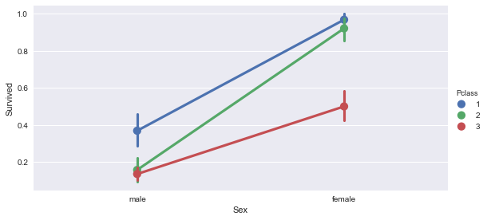

```python
sns.factorplot('Sex', 'Survived', hue='Pclass', size=4, aspect=2, data=train)
```

## 5. Getting Ready to Make Predictions

### Step 1: Clean the data

Recall that when we looked at the data in the training set, there were many values that were `NaN`, or in other words `NULL`.

```python
train.head(3)
```

|  | PassengerId | Survived | Pclass | Name | Sex | Age | SibSp | Parch | Ticket | Fare | Cabin | Embarked |
| --- | --- | --- | --- | --- | --- | --- | --- | --- | --- | --- | --- | --- |
| 0 | 1 | 0 | 3 | Braund, Mr. Owen Harris | male | 22.0 | 1 | 0 | A/5 21171 | 7.2500 | NaN | S |
| 1 | 2 | 1 | 1 | Cumings, Mrs. John Bradley (Florence Briggs Th... | female | 38.0 | 1 | 0 | PC 17599 | 71.2833 | C85 | C |
| 2 | 3 | 1 | 3 | Heikkinen, Miss. Laina | female | 26.0 | 0 | 0 | STON/O2. 3101282 | 7.9250 | NaN | S |

This can make cause issues when we're trying to analyze the data or iterate and access information that is non-existent. A simply way to fix this is to remove any NULLs by replacing it with something else.

#### Idea 1: Replace NaNs with the median value for easier computation

```python
for dataset in [train, test]:
    dataset['Fare'] = dataset['Fare'].fillna(train['Fare'].median())

for dataset in [train, test]:
    age_avg = dataset['Age'].mean()
    age_std = dataset['Age'].std()
    print age_avg
    age_null_count = dataset['Age'].isnull().sum()

    age_null_random_list = np.random.randint(age_avg - age_std, age_avg + age_std, size=age_null_count)
    dataset['Age'][np.isnan(dataset['Age'])] = age_null_random_list
    dataset['Age'] = dataset['Age'].astype(int)

train['AgeBand'] = pd.cut(train['Age'], 5)

print (train[['AgeBand', 'Survived']].groupby(['AgeBand'], as_index=False).mean())
```

```
29.6991176471
30.2725903614
         AgeBand  Survived
0  (-0.08, 16.0]  0.535714
1   (16.0, 32.0]  0.343249
2   (32.0, 48.0]  0.385496
3   (48.0, 64.0]  0.434783
4   (64.0, 80.0]  0.090909
```

#### Idea 2: Organize data into easier parseable forms

```python
for dataset in [train, test]:
    dataset.loc[ dataset['Age'] <= 16, 'Age'] = 0
    dataset.loc[(dataset['Age'] > 16) & (dataset['Age'] <= 32), 'Age'] = 1
    dataset.loc[(dataset['Age'] > 32) & (dataset['Age'] <= 48), 'Age'] = 2
    dataset.loc[(dataset['Age'] > 48) & (dataset['Age'] <= 64), 'Age'] = 3
    dataset.loc[ dataset['Age'] > 64, 'Age'] = 4

for dataset in [train, test]:
    dataset['Sex'] = dataset['Sex'].map( {'female': 1, 'male': 0} ).astype(int)

train.head()
```

|  | PassengerId | Survived | Pclass | Name | Sex | Age | SibSp | Parch | Ticket | Fare | Cabin | Embarked | AgeBand |
| --- | --- | --- | --- | --- | --- | --- | --- | --- | --- | --- | --- | --- | --- |
| 0 | 1 | 0 | 3 | Braund, Mr. Owen Harris | 0 | 1 | 1 | 0 | A/5 21171 | 7.2500 | NaN | S | (16.0, 32.0] |
| 1 | 2 | 1 | 1 | Cumings, Mrs. John Bradley (Florence Briggs Th... | 1 | 2 | 1 | 0 | PC 17599 | 71.2833 | C85 | C | (32.0, 48.0] |
| 2 | 3 | 1 | 3 | Heikkinen, Miss. Laina | 1 | 1 | 0 | 0 | STON/O2. 3101282 | 7.9250 | NaN | S | (16.0, 32.0] |
| 3 | 4 | 1 | 1 | Futrelle, Mrs. Jacques Heath (Lily May Peel) | 1 | 2 | 1 | 0 | 113803 | 53.1000 | C123 | S | (32.0, 48.0] |
| 4 | 5 | 0 | 3 | Allen, Mr. William Henry | 0 | 2 | 0 | 0 | 373450 | 8.0500 | NaN | S | (32.0, 48.0] |

## 6. Classification

There are many ways to classify data:

- Logistic Regression
- Support Vector Machines (SVC)
- Linear SVC
- k-Nearest Neighbor (KNN)
- Decision Tree
- Random Forest
- Naive Bayes (GaussianNB)
- Perceptron
- Stochastic Gradient Descent (SGD)

Here's the training and testing procedure:

1. Train these classifiers with our training data.
2. sing the trained classifier, we predict the Survival outcome of test data.
3. We calculate the accuracy score (in percentange) of the trained classifier.

```python
# All dem modules
from sklearn.linear_model import LogisticRegression
from sklearn.svm import SVC, LinearSVC
from sklearn.neighbors import KNeighborsClassifier
from sklearn.tree import DecisionTreeClassifier
from sklearn.ensemble import RandomForestClassifier
from sklearn.naive_bayes import GaussianNB
from sklearn.linear_model import Perceptron
from sklearn.linear_model import SGDClassifier
```

### Step 1: Feature Selection

Select the features that are relevant to your prediction. In this case, we are only looking at gender and class.

```python
train_features = ['Survived', 'Pclass', 'Sex']
train_data = train[train_features]

test_features = ['PassengerId', 'Pclass', 'Sex']
test_data = test[test_features]
```

```python
x_train = train_data.drop('Survived', axis=1)
y_train = train_data['Survived']
x_test = test_data.drop("PassengerId", axis=1).copy()

x_train.shape, y_train.shape, x_test.shape
```

```
((891, 2), (891,), (418, 2))
```

```python
clf = DecisionTreeClassifier()
clf.fit(x_train, y_train)
y_pred_decision_tree = clf.predict(x_test)
acc_decision_tree = round(clf.score(x_train, y_train) * 100, 2)
print (acc_decision_tree)
```

```
78.68
```

```python
clf = LogisticRegression()
clf.fit(x_train, y_train)
y_pred_log_reg = clf.predict(x_test)
acc_log_reg = round( clf.score(x_train, y_train) * 100, 2)
print (str(acc_log_reg) + ' percent')
```

```
78.68 percent
```

### Adding Features

What if we add Age as a feature of consideration?

```python
train_features = ['Survived', 'Pclass', 'Sex', 'Age']
train_data = train[train_features]

test_features = ['PassengerId', 'Pclass', 'Sex', 'Age']
test_data = test[test_features]

x_train = train_data.drop('Survived', axis=1)
y_train = train_data['Survived']
x_test = test_data.drop("PassengerId", axis=1).copy()

x_train.shape, y_train.shape, x_test.shape
```

```
((891, 3), (891,), (418, 3))
```

```python
clf = DecisionTreeClassifier()
clf.fit(x_train, y_train)
y_pred_decision_tree = clf.predict(x_test)
acc_decision_tree = round(clf.score(x_train, y_train) * 100, 2)
print (acc_decision_tree)
```

```
80.47
```

```python
clf = LogisticRegression()
clf.fit(x_train, y_train)
y_pred_log_reg = clf.predict(x_test)
acc_log_reg = round( clf.score(x_train, y_train) * 100, 2)
print (str(acc_log_reg) + ' percent')
```

```
78.56 percent
```

```python
submission = pd.DataFrame({
        "PassengerId": test["PassengerId"],
        "Survived": y_pred_decision_tree
    })

print submission.tail()
```

```
     PassengerId  Survived
413         1305         0
414         1306         1
415         1307         0
416         1308         0
417         1309         0
```